# Multilevel Model for Agricultural Sciences

Brendi Ang

17/10/2021

# Agricultural Science

## Exploring the dataset with basic linear model

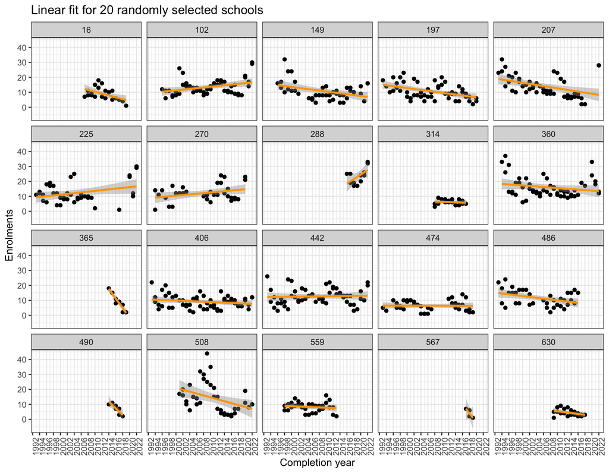

Figure 1: Basic linear model for 20 randomly selected schools to provide an at-a-glance visualisation of enrolment trends within schools for Agricultural Science subject

Figure 1 fits a linear model for 20 randomly selected schools. In most of these selected schools, the linear model captured a downward trend in enrolments. Some schools showed a increase, and in particular, school 288 showed a significant increase in enrolments as compared to the other selected schools. It seems that most schools that ceased offering the subject in the later years (*e.g.* schools 365, 490, 567) showed a large downward trend before ceasing the subject. Interestingly, school 508 displayed a rather cubic trend, where enrolments increases exponentially from 2002 before decrease till 2015 and picking up again.

## Getting the data ready for modelling

### Linearise response variable using log transformation

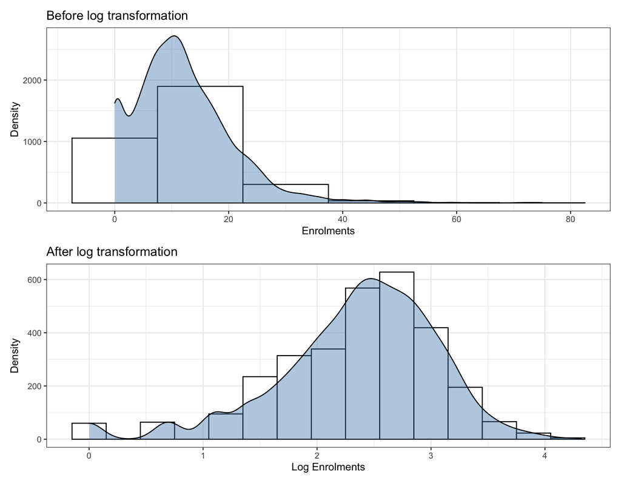

Figure 2: Effects of log transformation for response variable (enrolments) in Agricultural Science subject

The enrolments were right skewed, which is likely to be attributed to the various school sizes (as seen in Figure 2). A log transformation was implemented to the response variable (*i.e.* `enrolments`) to allow the the multilevel model to better capture the enrolment patterns.

## Unconditional means model

Table 1: AIC values for all candidate models for Agricultural Science

|  | df | AIC |
| --- | --- | --- |
| Model0.1: Schools nested within postcodes | 4 | 5146.230 |
| Model0.0: Within schools | 3 | 5149.113 |
| Model0.2: Schools nested within districts | 4 | 5149.856 |

### Intraclass correlation ($ICC$)

```r
summary(model0.1)
```

```
## Random effects:
```

```
##  Groups                         Name        Variance Std.Dev.
##  qcaa_school_id:school_postcode (Intercept) 0.40515  0.63651
##  school_postcode                (Intercept) 0.12275  0.35036
##  Residual                                   0.29180  0.54018
```

```
##
##  Fixed effects:
```

```
##             Estimate Std. Error  t value
## (Intercept) 2.018581 0.07739906 26.08017
```

```
##
##  Number of schools (level-two group) = 112
##  Number of school postcodes (level-three group) = 81
```

This model will takes into account 112 schools nested in 81 postcodes. In a three-level multilevel model, two intraclass correlations can be obtained using the model summary output above:

The **level-two ICC** relates to the correlation between school $i$ from a certain postcode $k$ in time $t$ and in time $t^* \ne t$:

$$\text{Level-two ICC} = \frac{\tau^{2}_{00}}{\tau^{2}_{00} + \phi^{2}_{00} + \sigma^2} = \frac{0.4052}{(0.4052 + 0.1228 + 0.2918)} = 0.4943$$

This can be conceptualised as the correlation between enrolments of two random draws from the same school at two different years. In other words, 49.45% of the total variability is attributable to the changes over time within schools.

The **level-three ICC** refers to the correlation between different schools $i$ and $i^*$ from a specific postcode $j$.

$$\text{Level-three ICC} = \frac{\phi^2_{00}}{\tau^2_{00} + \phi^2_{00} + \sigma^2} = \frac{0.1228}{(0.4052 + 0.1228 + 0.2918)} = 0.1498$$

Likewise, this can be loosely translated to be the correlation between enrolments of two random draws from two schools from two different postcode. In this case, 14.98% of the total variability is due to the difference between postcodes.

## Unconditional growth model

The unconditional growth model introduces the time predictor at level one, the model specification can be found in step 4. This allows for assessing within-school variability which can be attributed to linear changes over time. Furthermore, variability in intercepts and slopes can be obtained to compare schools within the same postcodes, and schools from different postcodes.

```r
summary(model1.0)
```

```
##  Groups                         Name        Variance  Std.Dev. Corr
##  school_postcode:qcaa_school_id (Intercept) 1.0049220 1.002458
##                                 year94      0.0013985 0.037397 -0.906
##  school_postcode                (Intercept) 0.1565287 0.395637
##                                 year94      0.0002277 0.015090 -0.669
##  Residual                                   0.2539595 0.503944
```

```
##               Estimate  Std. Error   t value
## (Intercept) 1.83876433 0.119841404 15.343314
## year94      0.01227337 0.004831677  2.540188
```

```
##  Number of Level Two groups =  112
##  Number of Level Three groups =  81
```

- $\pi_{0ij}$ = 1.8388: Initial status for school $i$ in postcode $j$ (*i.e.* expected log enrolments when time = 0)
- $\pi_{1ij}$ = 0.0123: Growth rate for school $i$ in postcode $j$
- $\epsilon_{tij}$ = 0.2540: Variance in within-school residuals after accounting for linear growth overtime

Enrolments were expected to increase by 1.2349% ($(e^{0.01227} - 1)\times100$) per year. The estimated within-schools variance decreased by 12.968% (0.2918 to 0.2539595), implying that 12.968% of within-school variability can be explained by the linear growth over time.

## Testing fixed effects

Table 2: AIC for all possible models with different combinations of fixed effects

| model | npar | AIC | BIC | logLik |
| --- | --- | --- | --- | --- |
| model4.3 | 13 | 4841.696 | 4919.622 | -2407.848 |
| model4.6 | 15 | 4841.897 | 4931.812 | -2405.949 |
| model4.5 | 15 | 4843.214 | 4933.129 | -2406.607 |
| model4.1 | 17 | 4843.639 | 4945.542 | -2404.819 |
| model4.0 | 19 | 4847.303 | 4961.195 | -2404.651 |
| model4.10 | 14 | 4848.524 | 4932.444 | -2410.262 |
| model4.9 | 14 | 4848.524 | 4932.444 | -2410.262 |
| model4.2 | 14 | 4848.524 | 4932.444 | -2410.262 |
| model4.8 | 14 | 4848.524 | 4932.444 | -2410.262 |
| model4.4 | 14 | 4850.301 | 4934.221 | -2411.151 |
| model4.7 | 16 | 4850.361 | 4946.270 | -2409.181 |

## Parametric bootstrap to test random effects

Table 3: Parametric Bootstrap to compare larger and smaller, nested model

| npar | AIC | BIC | logLik | deviance | Chisq | Df | Pr_boot(>Chisq) |
| --- | --- | --- | --- | --- | --- | --- | --- |
| 11 | 4837.855 | 4903.793 | -2407.928 | 4815.855 | NA | NA | NA |
| 13 | 4841.696 | 4919.622 | -2407.848 | 4815.696 | 0.1593719 | 2 | 0.718 |

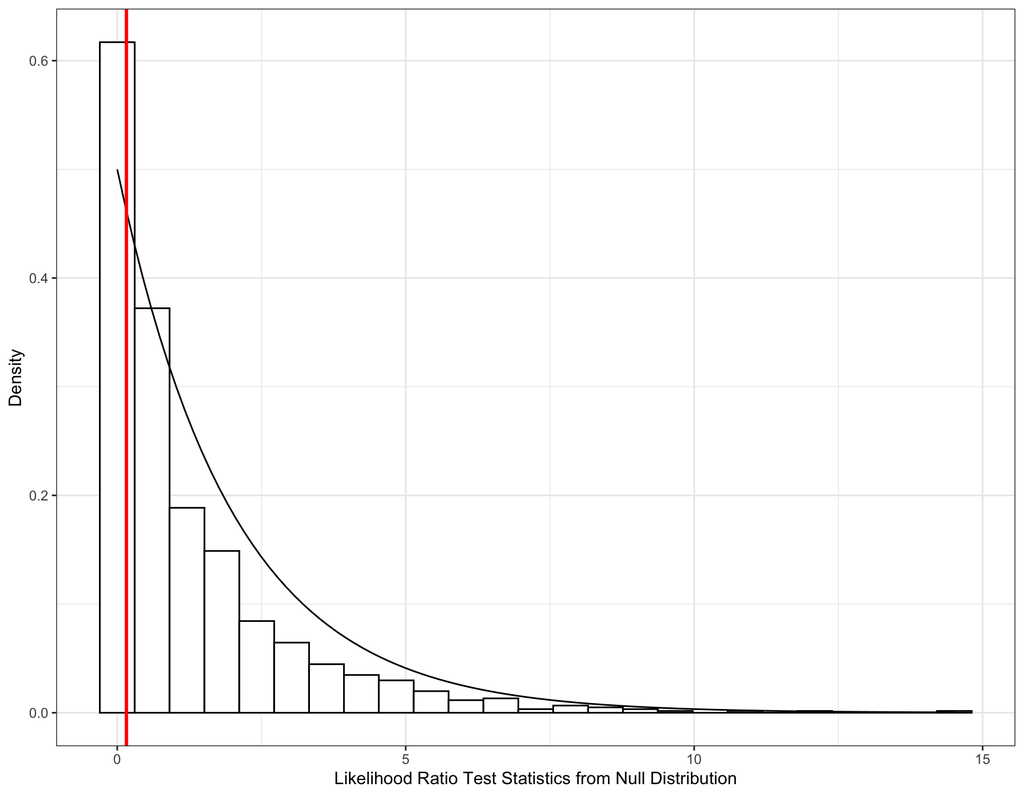

Figure 3: Histogram of likelihood ratio test statistic, with a red vertical line indicating the likelihood ratio test statistic for the actual model

The parametric bootstrap is used to approximate the likelihood ratio test statistic to produce a more accurate p-value by simulating data under the null hypothesis (detailed explanation can be found in step 7. Figure 3 displays the likelihood ratio test statistic from the null distribution, with the red line indicates the likelihood ratio test statistic using the actual data.

## Confidence interval

Table 4: 95% confidence intervals for fixed and random effects in the final model

| var | 2.5 % | 97.5 % |
| --- | --- | --- |
| sd_(Intercept)\|school_postcode:qcaa_school_id | 0.8530526 | 1.2182627 |
| cor_year94.(Intercept)\|school_postcode:qcaa_school_id | -0.9690616 | -0.8565112 |
| sd_year94\|school_postcode:qcaa_school_id | 0.0315056 | 0.0460868 |
| sd_(Intercept)\|school_postcode | 0.0000009 | 0.4581153 |
| sigma | 0.4876907 | 0.5140716 |
| (Intercept) | 1.4227924 | 2.2504155 |
| year94 | 0.0005497 | 0.0184106 |
| sectorGovernment | -0.3117705 | 0.4153108 |
| sectorIndependent | -0.0628937 | 0.7950850 |
| unityear_12_enrolments | -0.2747165 | -0.1289871 |
| year94:unityear_12_enrolments | 0.0026651 | 0.0107254 |

The parametric bootstrap is utilised to construct confidence intervals (as detailed in step 8). If the confidence intervals for the random effects does not include 0, it provides statistical evidence that the p-value is less than 0.5. In other words, it suggests that the random effects and the correlation between the random effects are significant at the 5% level.

## Interpreting final model

### Composite model

- Level one (measurement variable)
  $$Y_{tij} = \pi_{0ij} + \pi_{1ij}year94_{tij} + \epsilon_{tij}$$
- Level two (schools within postcodes)
  $$\begin{aligned} \pi_{0ij} &= \beta_{00j} + \beta_{01j}sector_{ij} + \beta_{02j}unit_{ij} + u_{0ij} \\ \pi_{1ij} &= \beta_{10j} + \beta_{11j}unit_{ij} + u_{1ij} \end{aligned}$$
- Level three (postcodes)
  $$\begin{aligned}\beta_{00j} &= \gamma_{000} + r_{00j} \\ \beta_{01j} &= \gamma_{010} + r_{01j} \\ \beta_{02j} &= \gamma_{020} + r_{02j} \\ \beta_{10j} &= \gamma_{100} \\ \beta_{11j} &= \gamma_{110} \end{aligned}$$

Therefore, the composite model can be written as:

$$\begin{aligned} Y_{tij} =\ & \pi_{0ij} + \pi_{1ij}year94_{tij} + \epsilon_{tij} \\ =\ & (\beta_{00j} + \beta_{01j}sector_{ij} + \beta_{02j}unit_{ij} + u_{0ij}) + (\beta_{10j} + \beta_{11j}unit_{ij} + u_{1ij})year94_{tij} + \epsilon_{tij} \\ =\ & \left[\gamma_{000} + r_{00j} + (\gamma_{010} + r_{01j})sector_{ij} + (\gamma_{020} + r_{02j})unit_{ij} + u_{0ij} \right] + \left[\gamma_{100} + \gamma_{110}unit_{ij} + u_{1ij}\right]year94_{tij} + \epsilon_{tij} \\ =\ & \left[\gamma_{0000} + \gamma_{010}sector_{ij} + \gamma_{020}unit_{ij} + \gamma_{100}year94_{tij} + \gamma_{110}unit_{ij}year94_{tij} \right] + \left[r_{00j} + r_{01j}sector_{ij} + r_{02j}unit_{ij} + u_{0ij} + u_{1ij}year94_{tij} + \epsilon_{tij} \right] \end{aligned}$$
### Fixed effects

```r
summary(model_f)
```

```
##  Groups                         Name        Variance  Std.Dev. Corr
##  school_postcode:qcaa_school_id (Intercept) 1.0717490 1.035253
##                                 year94      0.0015528 0.039406 -0.916
##  school_postcode                (Intercept) 0.0812513 0.285046
##  Residual                                   0.2507071 0.500707
```

```
##                                   Estimate  Std. Error    t value
## (Intercept)                    1.821947999 0.198742787  9.1673667
## year94                         0.009460629 0.004666531  2.0273366
## sectorGovernment               0.048533174 0.176743531  0.2745966
## sectorIndependent              0.364311290 0.196685041  1.8522572
## unityear_12_enrolments        -0.204347826 0.037573894 -5.4385587
## year94:unityear_12_enrolments  0.006683023 0.002232326  2.9937484
```

```
##  Number of Level Two groups =  112
##  Number of Level Three groups =  81
```

Notably, the model assumes that enrolments in different postcodes are assumed to increase at the same rate (as justified by the parametric bootstrap while testing for random effects). Using the model output above (see step 9 for detailed explanation on fixed effects), the estimated increase in mean enrolments for schools between postcodes are estimated to increase at a rate of 0.9506% per year.

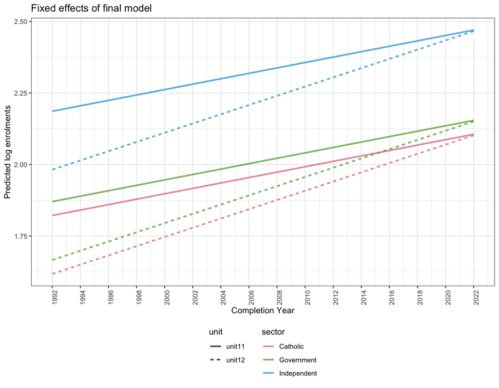

Figure 4: Fixed effects of the final model for Agricultural Science

Based on the fixed effects, independent schools are expected to have the highest enrolments over the years. In all sectors, unit 12 have lower initial status (*i.e.* lower enrolments when subject is first introduced), however, they are expected to increase at a much higher rate relative to unit 11 units. Intuitively, this suggests that on average, there may be more students taking this subject in year 10, before re-enrolling again in year 12, or in the more extreme case, students are dropping the subject after completing year 11.

### Random effects

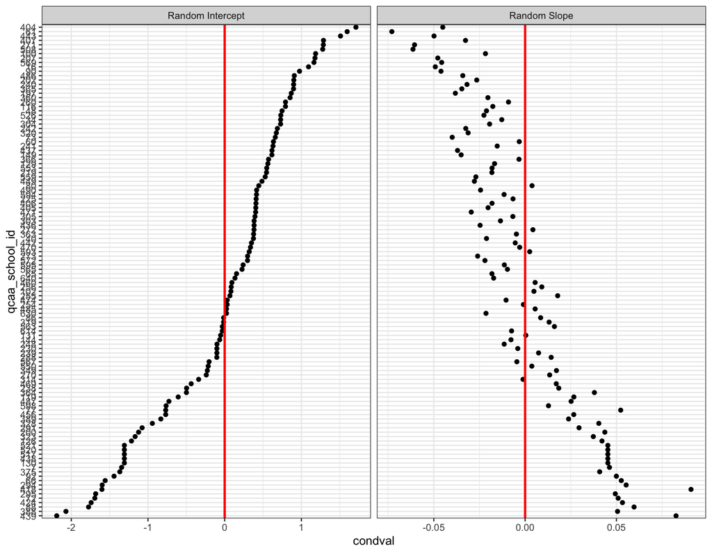

A clear negative correlation in the random intercept and slope can be distinguished, indicating that schools with larger enrolments when the subject was first introduced are expected to show a smaller increase (decrease) in enrolments over the years. Based on the model output, the correlation between random intercept and slope was -0.92.

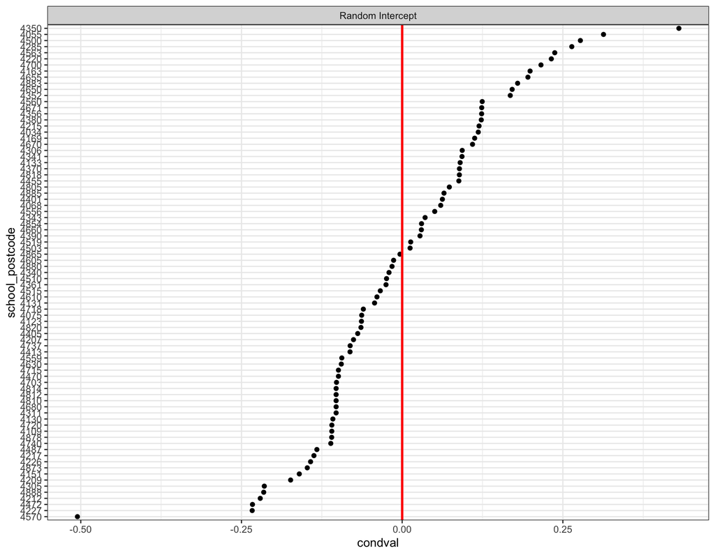

### Predictions

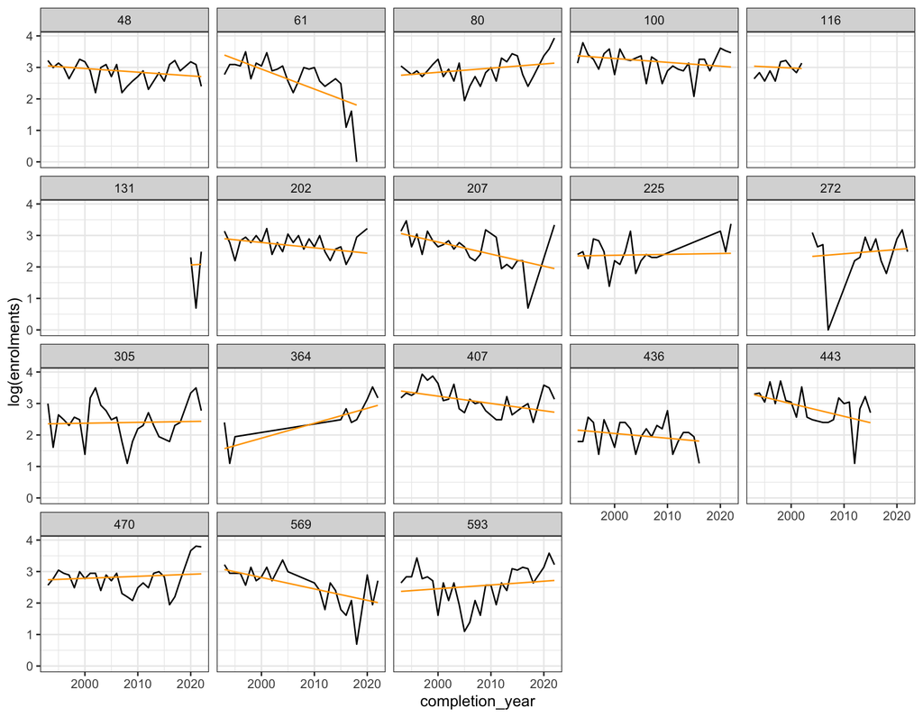